# An Introduction to the Structural Topic Model (STM)

THIS IS INCOMPLETE AND HAS A FEW VERY LONG RUN TIME COMMANDS. PROCEED WITH CAUTION.

This tutorial uses the example from the **stm** vignette as a starting point.

```r
# install the following packages as necessary
library(lda)
library(slam)
library(stm)
```

## Reading and preparing data in **stm**

For this example, we will use a variant of the “PoliBlogs08” data set (Eisenstein and Xing 2010), an example used in the **stm** vignette. The original data consists of 13246 blogposts scraped from 6 blogs, along with a “rating” as “Conservative” or “Liberal.”

```r
poliblogsFull <- read.csv("poliblogs2008.csv", colClasses = c("character", "character", "character", "factor", "integer", "factor"))
summary(poliblogsFull)
```

```
      X              documents           docname
 Length:13246       Length:13246       Length:13246
 Class :character   Class :character   Class :character
 Mode  :character   Mode  :character   Mode  :character



          rating          day         blog
 Conservative:7582   Min.   :  1.0   at :3197
 Liberal     :5664   1st Qu.:110.0   db :1879
                     Median :201.0   ha :3708
                     Mean   :193.5   mm : 677
                     3rd Qu.:277.0   tp :2080
                     Max.   :366.0   tpm:1705
```

For exposition purposes later, it will help to note some basics here. The `day` variable indicates the day of 2008 the blog was written, running from 1 to 366 since 2008 was a leap year. The `blog` variable indicates which one of the following six blogs posted the text for that observation:

- db: Digby (Liberal, single author [? not sure that’s true])
- tp: Think Progress (Liberal, multiple authors)
- tpm: Talking Points Memo (Liberal, multiple authors)
- mm: Michelle Malkin (Conservative, single author)
- at: American Thinker (Conservative, multiple authors)
- ha: Hot Air (Conservative, single author)

Variants of this example are available in different places, for STM as well as LDA, SAGE, and a variety of topic models. It’s easy to get confused. There are a variety of prefit STM models for this data that you can download from http://www.princeton.edu/~bms4/VignetteObjects.RData. These are stored in `poliblogPrevFit`, `poliblogContent`, and `poliblogInteraction` and a prerun STM model selection object stored in `poliblogSelect`. They are run on the object `out` that is created on page 9 of the **stm** vignette, and includes 13426 documents and 9244 terms (the terms that appear in more than 15 documents). We will avoid reusing these variable names (running commands directly from the provided vignette will do so).

Also provided in the package are the **stm** input objects for a *sample* of 5000 blogs, which we will use here for illustration purposes. These objects are stored in `poliblog5k.docs` (word counts in **stm** format), `poliblog5k.voc` (the vocabulary), and `poliblog5k.meta` (the metadata).

The `meta` object also contains a small snippet - up to 50 characters - of the text in a (confusing) list column `poliblog5k.meta$text`. We will create our own slightly larger snippets - 200 characters - for use in diagnostics later.

Let’s take a look at the first three documents in all three of these formats:

```r
poliblog5k.sample <- as.integer(rownames(poliblog5k.meta))
poliblog5k.fulltext <- poliblogsFull$documents[poliblog5k.sample]
poliblog5k.shorttext <- substr(poliblog5k.fulltext,1,200)
poliblog5k.meta$text[1:3]
```

```
[[1]]
[1] "How happy do you think Team Barry is that, thanks"

[[2]]
[1] "Tough stuff, but conservative passions this year"

[[3]]
[1] "Epic Ideological Failby digbyBefore you listen to"
```

```r
poliblog5k.shorttext[1:3]
```

```
[1] "How happy do you think Team Barry is that, thanks to Clark, the big soundbite from Obama’s latest peroration is going to be his tribute to McCain’s patriotism instead of his own?  Here’s the clip, in "
[2] "Tough stuff, but conservative passions this year have always been more anti-Obama than pro-McCain (at least until Palin joined the ticket) so I’m curious what you guys think.  Nate Silver, a lefty but"
[3] "Epic Ideological Failby digbyBefore you listen to one more wingnut try to tell you that the financial crisis and global recession was caused by irresponsible black people, illegal immigrants and Fanni"
```

```r
poliblog5k.fulltext[1:3]
```

```
[1] "How happy do you think Team Barry is that, thanks to Clark, the big soundbite from Obama’s latest peroration is going to be his tribute to McCain’s patriotism instead of his own?  Here’s the clip, in which Clark isn’t named but is clearly enough the target.  Today’s disquisition follows in the …
[2] "Tough stuff, but conservative passions this year have always been more anti-Obama than pro-McCain (at least until Palin joined the ticket) so I’m curious what you guys think.  Nate Silver, a lefty but one who usually plays it straight in his poll analyses, gives Maverick a five percent chance a…
[3] "Epic Ideological Failby digbyBefore you listen to one more wingnut try to tell you that the financial crisis and global recession was caused by irresponsible black people, illegal immigrants and Fannienfreddie, take this short, simple trip down memory lane with economist Joseph Stiglitz in the …
```

Note from the full text, especially the third one there from the “Digby” blog, that these were not parsed very carefully (by the original researchers in 2008). Most will tell you not to worry about that. They’re wrong.

### Preprocessing within the **stm** package

The *stm* package converts a vector of text and a dataframe of metadata into **stm** formatted objects using the command `textProcessor` which calls the package **tm** for its preprocessing routines.

```r
# * default parameters
poliblog5k.proc <- textProcessor(documents=poliblog5k.fulltext,
                                 metadata = poliblog5k.meta,
                                 lowercase = TRUE, #*
                                 removestopwords = TRUE, #*
                                 removenumbers = TRUE, #*
                                 removepunctuation = TRUE, #*
                                 stem = TRUE, #*
                                 wordLengths = c(3,Inf), #*
                                 sparselevel = 1, #*
                                 language = "en", #*
                                 verbose = TRUE, #*
                                 onlycharacter = TRUE, # not def
                                 striphtml = FALSE, #*
                                 customstopwords = NULL, #*
                                 v1 = FALSE) #*
```

```
Building corpus...
Converting to Lower Case...
Removing punctuation...
Removing stopwords...
Removing numbers...
Stemming...
```

```
provided 5000 variables to replace 1 variables
```

```
Creating Output...
```

The processed object is a list of four objects: `documents`, `vocab`, `meta`, and `docs.removed`. The `documents` object is a list, one per document, of 2 row matrices; the first row indicates the index of a word found in the document, and the second row indicates the (nonzero) counts. If preprocessing causes any documents to be empty, they are removed, as are the corresponding rows of the `meta` object.

These objects are in turn passed to the `prepDocuments` function, which filters vocabulary, and again removes empty documents and corresponding rows in the metadata. The authors of **stm** say it struggles with extremely large vocabularies, and in the vignette example filter to under 10000 terms by eliminating those terms that don’t appear in more than 15 documents. The data objects provided in the package or `poliblog5k` seem to filter out terms that don’t appear in more than 50 documents, leaving about 2600-2800 terms.

```r
poliblog5k.out <- prepDocuments(poliblog5k.proc$documents, poliblog5k.proc$vocab, poliblog5k.proc$meta, lower.thresh=50)
```

```
Removing 27200 of 29917 terms (148730 of 850617 tokens) due to frequency
Your corpus now has 5000 documents, 2717 terms and 701887 tokens.
```

(The number of terms, 2717, is more than the 2632 in the provided `poliblog5k.voc`. The mismatches seem to be in words with punctuation in the middle – like “re-elect” or “you’re” – and I can’t seem to make them match exactly with textProcessor options.)

### Preprocessing within **quanteda**

We’ve mostly read in and processed data with **quanteda**, so it’s worth noting that you can do that and then use the `convert` function to convert to **stm** and a variety of other formats.

```r
library(quanteda)
poliblog5k.fullmeta <- data.frame(doc_id=rownames(poliblog5k.meta), poliblog5k.meta, shorttext=poliblog5k.shorttext, fulltext=poliblog5k.fulltext, stringsAsFactors=FALSE)
poliblog5k.corpus <- quanteda::corpus(poliblog5k.fullmeta, docid_field="doc_id",text_field="fulltext")
poliblog5k.dfm <- quanteda::dfm(poliblog5k.corpus,
                                tolower=TRUE,
                                stem=TRUE,
                                remove=stopwords("english"),
                                remove_numbers=TRUE,
                                remove_punct=TRUE,
                                remove_symbols=TRUE,
                                ngrams=1)
dim(poliblog5k.dfm)
```

```
[1]  5000 50853
```

Again, let’s trim that to words appearing in more than 50 documents.

```r
poliblog5k.dfm <- dfm_trim(poliblog5k.dfm, min_docfreq=51, docfreq_type="count")
dim(poliblog5k.dfm)
```

```
[1] 5000 2659
```

Yet another slightly different count.

In any case, we convert to **stm** format using

```r
poliblog5k.dfm2stm <- quanteda::convert(poliblog5k.dfm, to = "stm")
names(poliblog5k.dfm2stm)
```

```
[1] "documents" "vocab"     "meta"
```

## Modeling without metadata structure

Let’s start with running this like a topic model without structure. It’s not exact, but this is very similar to the SAGE (Eisenstein, et al.) sparse estimation of a model with a correlated topic model (CTM) generative process (Blei, et al.)

```r
# Spectral initialization is advised by the authors
#    Should replicate exactly under spectral initialization
#
# This takes about 30 seconds.
poliblog5k.fit.nometa <- stm(documents = poliblog5k.docs,
                     vocab = poliblog5k.voc,
                     K = 20,
                     max.em.its = 75,
                     data = poliblog5k.meta,
                     init.type = "Spectral")
```

```
Beginning Spectral Initialization
     Calculating the gram matrix...
     Finding anchor words...
    ....................
     Recovering initialization...
    ..........................
Initialization complete.
....................................................................................................
Completed E-Step (4 seconds).
Completed M-Step.
Completing Iteration 1 (approx. per word bound = -7.057)
....................................................................................................
Completed E-Step (3 seconds).
Completed M-Step.
Completing Iteration 2 (approx. per word bound = -6.964, relative change = 1.323e-02)
....................................................................................................
Completed E-Step (4 seconds).
Completed M-Step.
Completing Iteration 3 (approx. per word bound = -6.935, relative change = 4.205e-03)
....................................................................................................
Completed E-Step (3 seconds).
Completed M-Step.
Completing Iteration 4 (approx. per word bound = -6.921, relative change = 1.924e-03)
....................................................................................................
Completed E-Step (3 seconds).
Completed M-Step.
Completing Iteration 5 (approx. per word bound = -6.914, relative change = 1.062e-03)
Topic 1: legisl, bill, presid, court, law
 Topic 2: democrat, republican, parti, conserv, gop
 Topic 3: think, peopl, like, know, one
 Topic 4: health, school, abort, care, women
 Topic 5: get, one, can, show, will
 Topic 6: obama, barack, campaign, polit, wright
 Topic 7: race, campaign, franken, vote, senat
 Topic 8: iran, israel, attack, will, terrorist
 Topic 9: obama, senat, said, biden, joe
 Topic 10: will, american, tax, economi, energi
 Topic 11: obama, mccain, poll, state, campaign
 Topic 12: iraq, war, iraqi, troop, militari
 Topic 13: one, time, report, year, new
```

[output cut: 88 more lines]

```
Completed E-Step (3 seconds).
Completed M-Step.
Completing Iteration 16 (approx. per word bound = -6.900, relative change = 1.869e-05)
....................................................................................................
Completed E-Step (3 seconds).
Completed M-Step.
Completing Iteration 17 (approx. per word bound = -6.900, relative change = 1.369e-05)
....................................................................................................
Completed E-Step (3 seconds).
Completed M-Step.
Completing Iteration 18 (approx. per word bound = -6.900, relative change = 1.002e-05)
....................................................................................................
Completed E-Step (3 seconds).
Completed M-Step.
Model Converged
```

```r
## suppress all this output with verbose=FALSE
```

We can get a detailed overview of key terms for every topic (or some) using the `labelTopics` command. This command provides the top words according to four different statistics, “highest probability” (just $\beta$), “FREX”, “Lift”, and “Score.” FREX is very similar to PMI and typically I find it most helpful.

```r
labelTopics(poliblog5k.fit.nometa)
```

```
OMP: Warning #96: Cannot form a team with 8 threads, using 2 instead.
OMP: Hint Consider unsetting KMP_DEVICE_THREAD_LIMIT (KMP_ALL_THREADS), KMP_TEAMS_THREAD_LIMIT, and OMP_THREAD_LIMIT (if any are set).
```

```
Topic 1 Top Words:
     Highest Prob: court, law, legisl, tortur, bill, presid, bush
     FREX: legisl, tortur, court, constitut, law, detaine, suprem
     Lift: legisl, surveil, detaine, judici, interrog, detent, guantanamo
     Score: legisl, tortur, court, detaine, law, interrog, cia
Topic 2 Top Words:
     Highest Prob: democrat, republican, parti, elect, will, conserv, vote
     FREX: republican, parti, democrat, conserv, pelosi, gop, progress
     Lift: lean, pelosi, centrist, nanci, republican, speaker, boehner
     Score: lean, republican, democrat, parti, gop, conserv, vote
Topic 3 Top Words:
     Highest Prob: think, peopl, like, say, know, one, just
     FREX: thing, linktocommentspostcount, postcounttb, guy, think, realli, someth
     Lift: sorri, digbyi, idiot, linktocommentspostcount, postcounttb, digbi, dday
     Score: sorri, think, linktocommentspostcount, postcounttb, guy, know, thing
Topic 4 Top Words:
     Highest Prob: women, school, children, care, abort, life, educ
     FREX: abort, school, children, gay, women, religi, educ
     Lift: stem, abort, gay, religi, birth, teach, cathol
     Score: stem, abort, school, church, women, gay, children
Topic 5 Top Words:
     Highest Prob: get, one, show, don, can, like, doesn
     FREX: film, doesn, isn, video, eastern, didn, don
     Lift: chat, seedubya, film, hollywood, clip, movi, scroll
     Score: chat, film, don, movi, eastern, didn, doesn
Topic 6 Top Words:
     Highest Prob: obama, barack, campaign, polit, wright, black, ayer
     FREX: wright, ayer, barack, obama, black, chicago, rezko
     Lift: rezko, wright, ayer, jeremiah, reverend, racist, racism
     Score: rezko, obama, wright, barack, ayer, campaign, jeremiah
Topic 7 Top Words:
     Highest Prob: race, senat, gop, campaign, rep, new, dem
     FREX: franken, coleman, rep, smith, minnesota, dem, race
     Lift: franken, coleman, smith, minnesota, mitch, mcconnel, norm
     Score: franken, coleman, dem, ballot, gop, minnesota, rep
Topic 8 Top Words:
     Highest Prob: iran, israel, attack, terrorist, will, nuclear, iranian
     FREX: israel, iran, isra, hama, iranian, terrorist, palestinian
     Lift: gaza, hama, isra, palestinian, israel, jew, osama
     Score: hama, iran, israel, isra, iranian, palestinian, nuclear
```

[output cut: 45 more lines]

```
Topic 18 Top Words:
     Highest Prob: report, investig, offici, offic, depart, case, state
     FREX: investig, blagojevich, attorney, depart, staff, appoint, prosecut
     Lift: blagojevich, rod, fbi, investig, probe, indict, prosecut
     Score: blagojevich, investig, attorney, depart, prosecut, fbi, prosecutor
Topic 19 Top Words:
     Highest Prob: money, financi, million, govern, billion, hous, market
     FREX: financi, bailout, mortgag, loan, earmark, taxpay, billion
     Lift: earmark, paulson, freddi, mae, subprim, treasuri, bailout
     Score: earmark, mortgag, bailout, billion, loan, paulson, market
Topic 20 Top Words:
     Highest Prob: hillari, clinton, primari, will, campaign, win, democrat
     FREX: hillari, clinton, deleg, primari, edward, nomin, michigan
     Lift: deleg, superdeleg, hillari, dnc, edward, clinton, super
     Score: deleg, hillari, clinton, superdeleg, primari, romney, edward
```

Going through these … rough guesses at the topics seem to be.

1. Law, esp re torture
2. Political parties
3. ???? Informal/personal, Digby, post junk (We’ll come back to this)
4. Seems to be a mixture: Religious issues (including abortion, gay rights, stem cells) and women / children / education
5. ???? Contractions? Movies? (We’ll come back to this)
6. Obama campaign (including Jeremiah Wright, Bill Ayers)
7. Senate
8. Middle East (Israel, Iran, Gaza, Hamas)
9. Joes? Biden / Lieberman.
10. Energy, oil/gas prices
11. General election polls
12. Wars - Iraq/Afghanistan
13. Mixture? Media/reporting and global warming
14. Bush administration
15. McCain campaign / Republican primary
16. Foreign affairs
17. Voting incl ACORN and voter fraud / illegal immigrants
18. Rod Blagojevich scandal
19. Financial crisis
20. Hillary Clinton / Democratic primary

Some of these look a bit “undercooked,” meaning a model with more topics might have separated them (e.g., 4 and 13). Some may be spurious (e.g., 9, which may be about Senators, may be about vice presidential possibilities, may be about the democratic primary, or may just be triggering on correlations with the word “Joe”). Some of these appear at first blush to be “junk” (e.g., 3 and 5).

We can get an overview of the distribution of these topics by plotting the fit object:

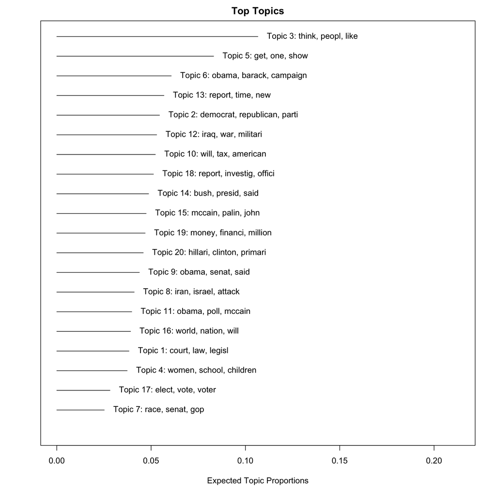

```r
plot(poliblog5k.fit.nometa)
```

We can find the top documents associated with a topic with the `findThoughts` function:

```r
findThoughts(poliblog5k.fit.nometa,texts = poliblog5k.fulltext, n = 2, topics = c(6))
```

```
 Topic 6:
     The New York Sun is reporting that Barack Obama repudiated the views of Nation of Islam leader Louis Farrakhan that were discussed in Richard Cohen's Washington Post column. Cohen's criticism regarding Obama's ties to the Church and the Pastor that gave an award to Farrakhan were reaching a lar…
    How far can 527 groups go before they create more of a backlash than forward momentum?  Opposing 527s have unveiled ads that may answer that question. A pro-Obama 527 makes an issue of McCain’s health and Sarah Palin’s inexperience, while a pro-McCain group talks about Obama’s connections with W…
```

These both appear to be conservative discussion of Obama and particularly associations with controversial people like Ayers and Wright. So that looks ok.

We can look at multiple, or all, topics this way as well. For this we’ll just look at the shorttext.

```r
findThoughts(poliblog5k.fit.nometa,texts = poliblog5k.shorttext, n = 3, topics = 1:20)
```

```
 Topic 1:
     As you may have heard by now, Barack Obama voted for the FISA cave-in bill in the Senate today, and Hillary voted against it.  Hillary has now explained her vote in a new statement...  The legislation
    New wiretapping bill dubbed ‘repugnant’ and ‘a capitulation.’                   Under a “compromise” wiretapping bill the House is expected to approve tomorrow, U.S. phone companies that cooperated with President
    In Radio Address, Bush Hypes Consequences of Wiretapping Law Expiration                     In his weekly radio address, President Bush not only blames Congress for tonight’s expiration of the Protect America Act,
 Topic 2:
     Two successive national-election losses still hasn’t clued Republicans into the need for dramatic change in their direction.  The House GOP caucus rejected a plan by John Boehner and Eric Cantor to im
    Here's yet more evidence that the Dems are poised for huge gains in Congress: The Cook Report has released a new set of updated rankings on 25 House races -- and all 25 are shifts in the Dems' directi
    This is really something. We already knew that House Dems are expected to rack up major victories this fall, but this latest development is really eye-opening.  The Cook Political Report, whose rating
 Topic 3:
     What's Wrong With This Picture?by digby Here are who the Telegraph considers to be the 50 most influential political pundits in America. The following are the top choices starting with number 10, Mark
    Tears Of A Clownby digby“I don’t think people look at me as the establishment, do you?” Matthews asked me. “Am I part of the winner’s circle in American life? I don’t think so.”I just read the Chris M
    “I think we’ve all been demeaned.”by tristeroIndeed we all have,, whether or not we ever saw a Swift Boat. But this is what movement conservatives do with emotionally weighty situations or actions. Th
 Topic 4:
     Washington University refuses to back down on Schlafly award.                      Today, Washington University chancellor Mark Wrighton finally responded to the intense criticism the school has been receiving over
    Right-Wing Ad Tries To Frighten Minorities By Comparing Embryonic Stem Cell Research To Tuskegee Study                      Up for consideration in Michigan is Proposal 2, a measure to permit embryonic stem cell res
    McCain spent about half of his speech yesterday to the N.A.A.C.P. outlining his education plans for America. The audience heard an approach much different than the plan proposed by Senator Obama.McCai
 Topic 5:
     The Northern Alliance Radio Network will be on the air today, with our eight-hour-long broadcast schedule starting at 9 am CT.  If you’re in the Twin Cities, you can hear us on AM 1280 The Patriot, or
    Today, on the Ed Morrissey Show (3 pm ET), we’re thrilled to welcome back Mary Katharine Ham.  MK and I will talk about the latest developments in the Blago-Rahma scandal, the Joe Scarborough takedown
    Just buying the tickets to this film felt like a guilty pleasure.  What could be more cheesy than a movie musical with serious actors like Meryl Streep, Julie Walters, Pierce Brosnan, Colin Firth, and
 Topic 6:
     The New York Sun is reporting that Barack Obama repudiated the views of Nation of Islam leader Louis Farrakhan that were discussed in Richard Cohen's Washington Post column. Cohen's criticism regardin
    How far can 527 groups go before they create more of a backlash than forward momentum?  Opposing 527s have unveiled ads that may answer that question. A pro-Obama 527 makes an issue of McCain’s health
    The Washington Post editorial board follows the lead in some ways of the New York Times, which pretends that Jeremiah Wright suddenly popped out of the ground this week, offering lunatic conspiracy th
 Topic 7:
     Here's tonight's run-down on the Congressional races:  Coleman Suspends Negative Ads, Sort Of Sen. Norm Coleman (R-MN), who has fallen behind in the polls against Al Franken thanks to the economic cri
```

[output cut: 54 more lines]

The first three in Topic 1 are about FISA and wiretapping … not torture … so that may be a more general “legislation / law” topic. The first three in Topic 13 are all about global warming, so that merits a closer inspection.

The `plotQuote` function will give you similar information in a more graphical format.

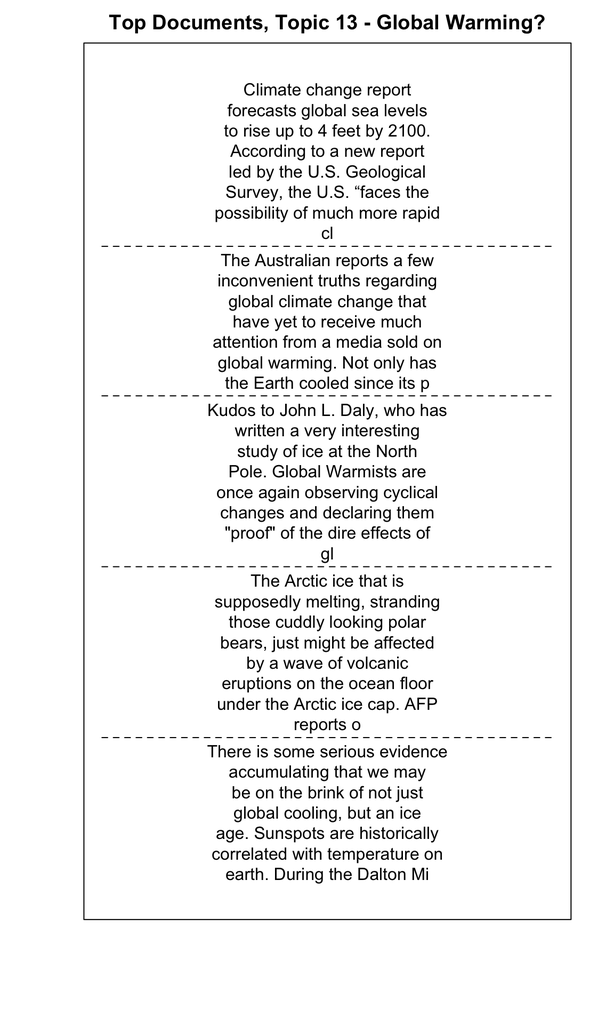

```r
firstdocs.13 <- findThoughts(poliblog5k.fit.nometa,texts = poliblog5k.shorttext, n = 5, topics = c(13))$docs[[1]]
plotQuote(firstdocs.13, main="Top Documents, Topic 13 - Global Warming?")
```

Or we can go back to words and our old friend the wordcloud:

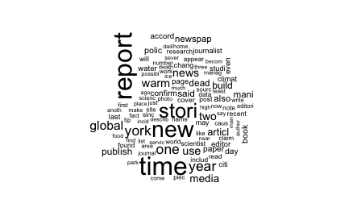

```r
cloud(poliblog5k.fit.nometa, topic=13, scale=c(2,.25))
```

Boy. It’s tough to call that “global warming.” The vast majority of those words are media related. We would really need to look closely at the documents to see what’s going on.

## Modeling with metadata

But let’s move on. STM’s bread and butter is in incorporating “structure” by modeling on metadata.

In the vignette example, the authors model “prevalence” of topics on “rating” and “s(day)”. The latter calculates a smoothed function (a b-spline) across the variable, appropriate for a variable like `day` that takes on continuous or many values.

Let’s do that.

```r
poliblog5k.fit.rat_day <- stm(documents = poliblog5k.docs,
                     vocab = poliblog5k.voc,
                     K = 20,
                     prevalence =~ rating + s(day),
                     max.em.its = 75,
                     data = poliblog5k.meta,
                     init.type = "Spectral",
                     verbose=FALSE)
```

Or we might think just rating matters.

```r
poliblog5k.fit.rat_only <- stm(documents = poliblog5k.docs,
                     vocab = poliblog5k.voc,
                     K = 20,
                     prevalence =~ rating,
                     max.em.its = 75,
                     data = poliblog5k.meta,
                     init.type = "Spectral",
                     verbose=FALSE)
```

Or we might think just day matters.

```r
poliblog5k.fit.day_only <- stm(documents = poliblog5k.docs,
                     vocab = poliblog5k.voc,
                     K = 20,
                     prevalence =~ s(day),
                     max.em.its = 75,
                     data = poliblog5k.meta,
                     init.type = "Spectral",
                     verbose=FALSE)
```

Or maybe it’s *blog* and day.

```r
poliblog5k.fit.blog_day <- stm(documents = poliblog5k.docs,
                     vocab = poliblog5k.voc,
                     K = 20,
                     prevalence =~ blog + s(day),
                     max.em.its = 75,
                     data = poliblog5k.meta,
                     init.type = "Spectral",
                     verbose=FALSE)
```

It turns out this makes almost no difference to the model. These documents are long enough that the influence of the prior from the covariate structure is imperceptible,

```r
# Beta for topic 1
cor(poliblog5k.fit.nometa$beta[[1]][[1]][1,],poliblog5k.fit.rat_day$beta[[1]][[1]][1,])
```

```
[1] 0.9999778
```

```r
cor(poliblog5k.fit.nometa$beta[[1]][[1]][1,],poliblog5k.fit.blog_day$beta[[1]][[1]][1,])
```

```
[1] 0.9999262
```

```r
cor(poliblog5k.fit.nometa$beta[[1]][[1]][1,],poliblog5k.fit.day_only$beta[[1]][[1]][1,])
```

```
[1] 0.9999967
```

```r
cor(poliblog5k.fit.nometa$beta[[1]][[1]][1,],poliblog5k.fit.rat_only$beta[[1]][[1]][1,])
```

```
[1] 0.9999822
```

```r
cor(poliblog5k.fit.nometa$theta[,1],poliblog5k.fit.rat_day$theta[,1])
```

```
[1] 0.999578
```

```r
cor(poliblog5k.fit.nometa$theta[,1],poliblog5k.fit.blog_day$theta[,1])
```

```
[1] 0.9989984
```

```r
cor(poliblog5k.fit.nometa$theta[,1],poliblog5k.fit.rat_only$theta[,1])
```

```
[1] 0.9998582
```

```r
cor(poliblog5k.fit.nometa$theta[,1],poliblog5k.fit.day_only$theta[,1])
```

```
[1] 0.9996832
```

The STM model *does* differ considerably in this example if you also model the *content* of topics as a function of covariates.

(This takes a bit longer, 2-3 minutes in this case.)

```r
poliblog5k.fit.cont.rat <- stm(documents = poliblog5k.docs,
                     vocab = poliblog5k.voc,
                     K = 20,
                     prevalence =~ rating + s(day),
                     content =~ rating,
                     max.em.its = 75,
                     data = poliblog5k.meta,
                     init.type = "Spectral",
                     verbose=FALSE)
```

```r
poliblog5k.labels_rat <- labelTopics(poliblog5k.fit.cont.rat)
poliblog5k.labels_rat
```

```
Topic Words:
 Topic 1: detaine, fisa, guantanamo, detent, surveil, judici, interrog
 Topic 2: republican, gop, boehner, pelosi, democrat, parti, centrist
 Topic 3: crap, conservat, elit, guy, blogospher, gender, tale
 Topic 4: abort, church, prolif, teach, birth, health, cathol
 Topic 5: movi, hollywood, song, limbaugh, mom, music, clip
 Topic 6: ayer, wright, obama, jeremiah, reverend, barack, rezko
 Topic 7: franken, coleman, minnesota, ballot, norm, incumb, recount
 Topic 8: iran, iranian, tehran, gaza, arabia, ahmadinejad, osama
 Topic 9: biden, joe, plumber, lieberman, graham, foreign, segment
 Topic 10: drill, coal, prosper, tax, economi, worker, gas
 Topic 11: gallup, rasmussen, poll, battleground, pennsylvania, undecid, nevada
 Topic 12: maliki, baghdad, iraqi, sadr, basra, shiit, petraeus
 Topic 13: ice, scientist, scienc, warm, emiss, anim, scientif
 Topic 14: olbermann, cbs, nbc, gibson, bias, keith, editor
 Topic 15: rudi, mccain, giuliani, maverick, palin, sarah, pow
 Topic 16: nato, russia, soviet, europ, russian, georgia, africa
 Topic 17: registr, acorn, fraud, worker, california, missouri, counti
 Topic 18: blagojevich, prosecutor, prosecut, attorney, investig, probe, impeach
 Topic 19: mae, bailout, paulson, treasuri, freddi, mortgag, earmark
 Topic 20: superdeleg, deleg, hillari, caucus, edward, iowa, clinton

 Covariate Words:
 Group Conservative: latter, afterward, especi, buri, surviv, finger, appar
 Group Liberal: matt, today, excerpt, shape, swift, current, overwhelm

 Topic-Covariate Interactions:
 Topic 1, Group Conservative: legislatur, jone, properti, democraci, appoint, raz, applic
 Topic 1, Group Liberal: mcconnel, prohibit, illeg, armi, nixon, human, graham

 Topic 2, Group Conservative: reid, mcconnel, mitch, drill, hurrican, pork, fiscal
 Topic 2, Group Liberal: digbi, turnout, elit, prolif, primari, cash, repudi

 Topic 3, Group Conservative: seedubya, exit, color, barri, religi, bless, religion
 Topic 3, Group Liberal: digbyi, digbi, bias, postcounttb, linktocommentspostcount, obsess, regim

 Topic 4, Group Conservative: park, neighborhood, wife, doctrin, dream, intellectu, signatur
 Topic 4, Group Liberal: huckabe, stem, pastor, evangel, christian, rev, thompson

 Topic 5, Group Conservative: morrissey, scroll, denver, seedubya, mitch, updat, indiana
```

[output cut: 31 more lines]

```

 Topic 16, Group Conservative: provinc, ship, ambassador, spi, gulf, villag, arrest
 Topic 16, Group Liberal: nuclear, weapon, afghanistan, enrich, taliban, global, pakistan

 Topic 17, Group Conservative: hispan, enforc, border, san, park, personnel, lobbi
 Topic 17, Group Liberal: gay, battleground, enact, turnout, africanamerican, plumber, court

 Topic 18, Group Conservative: lobbyist, immun, fundrais, reelect, congressman, mayor, alaska
 Topic 18, Group Liberal: moham, homeland, guantanamo, applic, bay, permiss, award

 Topic 19, Group Conservative: crap, enrich, johnson, inspector, graham, discrimin, perman
 Topic 19, Group Liberal: deficit, infrastructur, unemploy, thinkfast, economist, oil, consum

 Topic 20, Group Conservative: ohio, nbc, ambassador, racial, gender, gore, defeat
 Topic 20, Group Liberal: romney, turnout, huckabe, oregon, fundrais, circul, grassroot
```

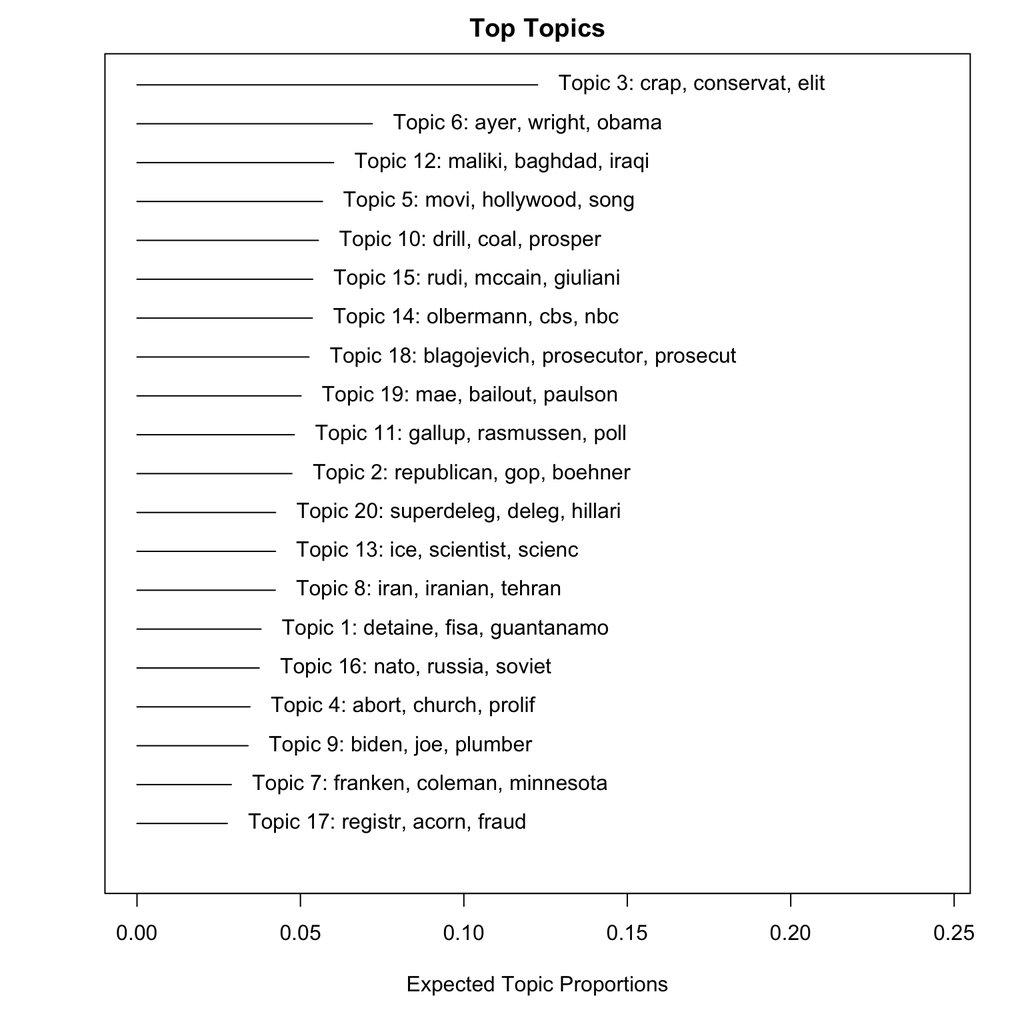

```r
plot(poliblog5k.fit.cont.rat)
```

The overall topic words seem to indicate the topics are now:

1. Rights? (Mixture of FISA/surveillance and Guantanamo/detention/torture)
2. Political parties
3. ???? “Garbage” … Again, I’ll come back to this.
4. Abortion? Religion?
5. Movies? Pop culture? (~= prev T5)
6. Obama and friends (~= prev T6)
7. Senate (~ prev T7)
8. Middle East (~ prev T8)
9. Joes? (~ prev T9)
10. Energy (~ pre T10)
11. Election horse race. (~ prev T11)
12. Iraq war. (~ prev T12)
13. Global warming / ice age (~ prev T13)
14. Media (~prev T14 and some T13)
15. Republican party / primary (~prev T15)
16. Foreign affairs (~prev T16)
17. Voter registration / fraud / ACORN
18. Blagojevich scandal
19. Financial crisis
20. Democratic primary / Hillary Clinton

We can estimate for multiple groups, like blog here. Be aware this takes considerably longer. About 8 minutes in the example below.

```r
system.time(
  poliblog5k.fit.cont.blog <- stm(documents = poliblog5k.docs,
                     vocab = poliblog5k.voc,
                     K = 20,
                     prevalence =~ blog + s(day),
                     content =~ blog,
                     max.em.its = 75,
                     data = poliblog5k.meta,
                     init.type = "Spectral",
                     verbose=FALSE)
)
```

```
   user  system elapsed
389.264  70.575 459.867
```

We can also estimate metadata interactions, with a binary moderatng variable.

```r
poliblog5k.fit.ratday.int <- stm(documents = poliblog5k.docs,
                     vocab = poliblog5k.voc,
                     K = 20,
                     prevalence =~ rating * s(day),
                     max.em.its = 75,
                     data = poliblog5k.meta,
                     init.type = "Spectral",
                     verbose=FALSE)
```

```r
poliblog5k.ratday.int.prep <- estimateEffect(formula = c(19) ~ rating*day, stmobj = poliblog5k.fit.ratday.int, metadata = poliblog5k.meta, uncertainty="None")
```

```r
plot(poliblog5k.ratday.int.prep, covariate = "day", model = poliblog5k.fit.ratday.int, method = "continuous", xlab = "Days", moderator = "rating", moderator.value = "Liberal", linecol = "blue", ylim = c(0, .12), printlegend = F)
plot(poliblog5k.ratday.int.prep, covariate = "day", model = poliblog5k.fit.ratday.int, method = "continuous", xlab = "Days", moderator = "rating", moderator.value = "Conservative", linecol = "red", add = T, printlegend = F)
```

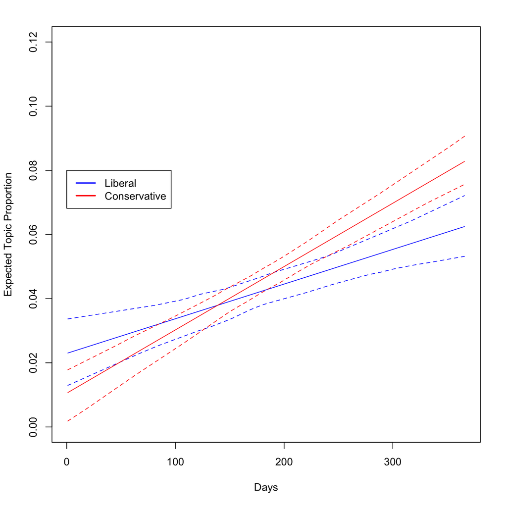

```r
legend(0, .08, c("Liberal", "Conservative"), lwd = 2, col = c("blue", "red"))
```

```r
estEffpoliblog <- estimateEffect(1:20 ~ rating + s(day), poliblog5k.fit.rat_day, meta = poliblog5k.meta, uncertainty = "Global")
summary(estEffpoliblog, topics=1)
```

```
Call:
estimateEffect(formula = 1:20 ~ rating + s(day), stmobj = poliblog5k.fit.rat_day,
    metadata = poliblog5k.meta, uncertainty = "Global")


Topic 1:

Coefficients:
                Estimate Std. Error t value Pr(>|t|)
(Intercept)    6.647e-05  1.432e-02   0.005 0.996297
ratingLiberal  2.008e-02  3.687e-03   5.446 5.41e-08 ***
s(day)1        7.033e-02  2.761e-02   2.547 0.010887 *
s(day)2        4.447e-02  1.798e-02   2.473 0.013430 *
s(day)3        1.032e-02  1.974e-02   0.523 0.601301
s(day)4        6.038e-02  1.810e-02   3.337 0.000855 ***
s(day)5        4.927e-02  1.830e-02   2.692 0.007133 **
s(day)6       -5.632e-03  1.683e-02  -0.335 0.737944
s(day)7        3.364e-02  1.834e-02   1.834 0.066684 .
s(day)8        8.047e-03  2.058e-02   0.391 0.695760
s(day)9        6.098e-02  2.228e-02   2.737 0.006231 **
s(day)10       1.347e-02  2.167e-02   0.622 0.534047
---
Signif. codes:
0 ‘***’ 0.001 ‘**’ 0.01 ‘*’ 0.05 ‘.’ 0.1 ‘ ’ 1
```

```r
poliblog5k.eff.day.nometa <- estimateEffect(1:20 ~ s(day), poliblog5k.fit.nometa, meta = poliblog5k.meta, uncertainty = "Global")
summary(poliblog5k.eff.day.nometa, topics=19)
```

```
Call:
estimateEffect(formula = 1:20 ~ s(day), stmobj = poliblog5k.fit.nometa,
    metadata = poliblog5k.meta, uncertainty = "Global")


Topic 19:

Coefficients:
             Estimate Std. Error t value Pr(>|t|)
(Intercept)  0.013862   0.015954   0.869  0.38495
s(day)1      0.065560   0.030989   2.116  0.03443 *
s(day)2      0.037224   0.017392   2.140  0.03238 *
s(day)3      0.003956   0.021425   0.185  0.85350
s(day)4      0.054261   0.019237   2.821  0.00481 **
s(day)5      0.036220   0.019670   1.841  0.06563 .
s(day)6     -0.003282   0.018759  -0.175  0.86112
s(day)7      0.029519   0.019765   1.494  0.13536
s(day)8      0.007867   0.022743   0.346  0.72944
s(day)9      0.053945   0.023438   2.302  0.02140 *
s(day)10     0.009722   0.022540   0.431  0.66624
---
Signif. codes:
0 ‘***’ 0.001 ‘**’ 0.01 ‘*’ 0.05 ‘.’ 0.1 ‘ ’ 1
```

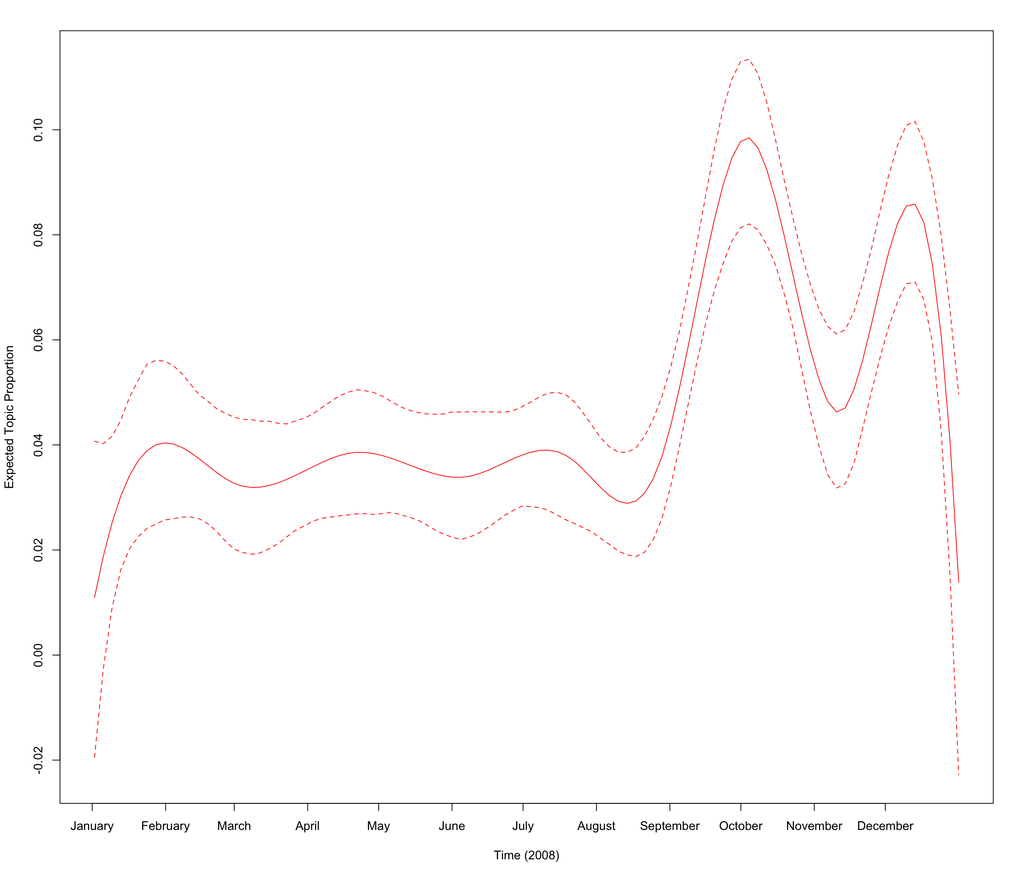

```r
plot(poliblog5k.eff.day.nometa, "day", method = "continuous", topics = 19,model = poliblog5k.fit.nometa, printlegend = FALSE, xaxt = "n", xlab = "Time (2008)")
monthseq <- seq(from = as.Date("2008-01-01"), to = as.Date("2008-12-01"), by = "month")
monthnames <- months(monthseq)
axis(1,at = as.numeric(monthseq) - min(as.numeric(monthseq)), labels = monthnames)
```

```r
poliblog5k.eff.day.rat_day <- estimateEffect(1:20 ~ s(day), poliblog5k.fit.rat_day, meta = poliblog5k.meta, uncertainty = "Global")
summary(poliblog5k.eff.day.rat_day, topics=19)
```

```
Call:
estimateEffect(formula = 1:20 ~ s(day), stmobj = poliblog5k.fit.rat_day,
    metadata = poliblog5k.meta, uncertainty = "Global")


Topic 19:

Coefficients:
             Estimate Std. Error t value Pr(>|t|)
(Intercept)  0.009106   0.014966   0.608  0.54293
s(day)1      0.075717   0.029789   2.542  0.01106 *
s(day)2      0.040852   0.018231   2.241  0.02508 *
s(day)3      0.008178   0.020515   0.399  0.69018
s(day)4      0.060850   0.018664   3.260  0.00112 **
s(day)5      0.047174   0.018575   2.540  0.01112 *
s(day)6     -0.005778   0.018954  -0.305  0.76048
s(day)7      0.037943   0.018143   2.091  0.03655 *
s(day)8      0.008792   0.023797   0.369  0.71179
s(day)9      0.061950   0.023306   2.658  0.00788 **
s(day)10     0.012290   0.022760   0.540  0.58922
---
Signif. codes:
0 ‘***’ 0.001 ‘**’ 0.01 ‘*’ 0.05 ‘.’ 0.1 ‘ ’ 1
```

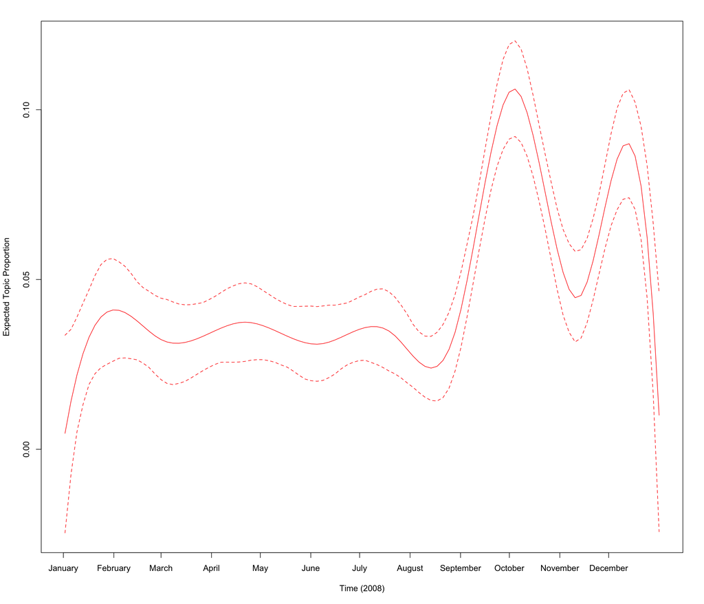

```r
plot(poliblog5k.eff.day.rat_day, "day", method = "continuous", topics = 19,model = poliblog5k.fit.rat_day, printlegend = FALSE, xaxt = "n", xlab = "Time (2008)")
monthseq <- seq(from = as.Date("2008-01-01"), to = as.Date("2008-12-01"), by = "month")
monthnames <- months(monthseq)
axis(1,at = as.numeric(monthseq) - min(as.numeric(monthseq)), labels = monthnames)
```

There is in fact a pattern to the garbage topics, if we model by blog.

```r
poliblog5k.eff.blog_day <- estimateEffect(1:20 ~ blog + s(day), poliblog5k.fit.blog_day, meta = poliblog5k.meta, uncertainty = "Global")
summary(poliblog5k.eff.blog_day, topics=3)
```

[output not shown]

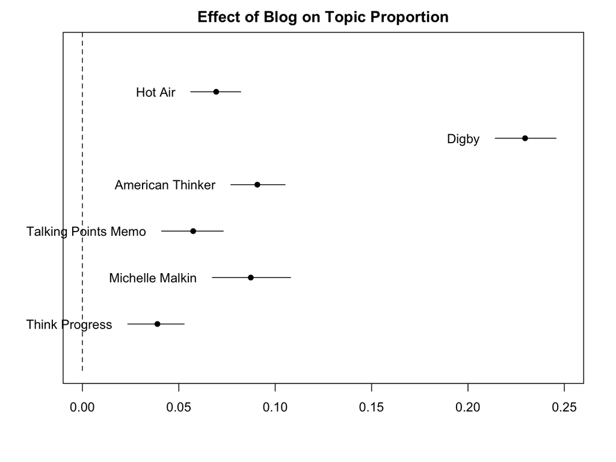

```r
plot(poliblog5k.eff.blog_day, covariate = "blog", topics = c(3), model = poliblog5k.fit.blog_day, method = "pointestimate",
     main = "Effect of Blog on Topic Proportion",
     xlim = c(0, .25), labeltype = "custom",
     custom.labels = c("Hot Air", "Digby", "American Thinker", "Talking Points Memo", "Michelle Malkin", "Think Progress"))
```

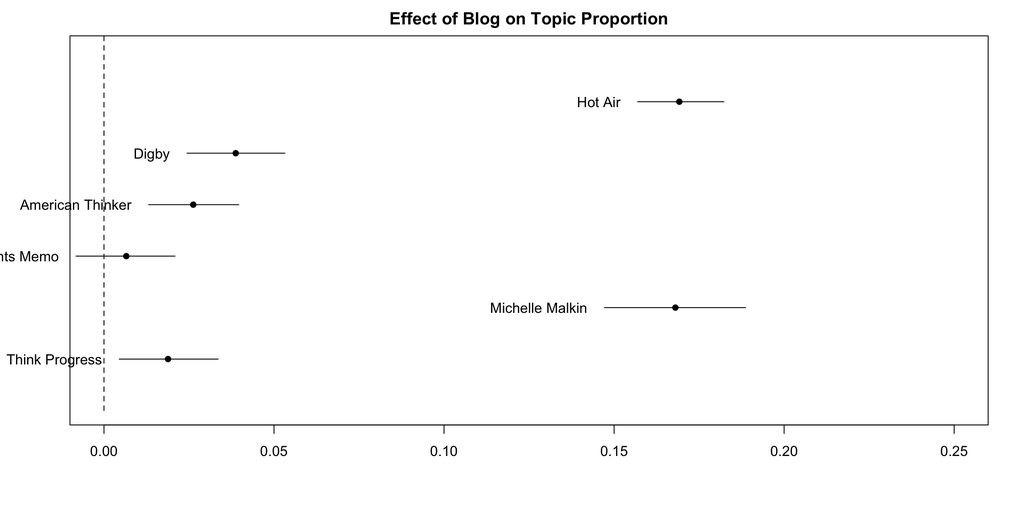

```r
plot(poliblog5k.eff.blog_day, covariate = "blog", topics = c(5), model = poliblog5k.fit.blog_day, method = "pointestimate",
     main = "Effect of Blog on Topic Proportion",
     xlim = c(0, .25), labeltype = "custom",
     custom.labels = c("Hot Air", "Digby", "American Thinker", "Talking Points Memo", "Michelle Malkin", "Think Progress"))
```

What does this imply for our topics as “topics”?

What does this imply for our estimates of “topic proportion”?

What does this imply for topic concentration parameters?

## Methods for Estimating / Inspecting Multiple Models / Choosing K

### Lee and Mimno’s Technique: Anchor Words via t-SNE

This takes about 6 *minutes* in this example.

```r
## requires installation of packages: Rtsne, rsvd, geometry
system.time(
  poliblog5k.fit.lee_mimno <- stm(documents = poliblog5k.docs,
                     vocab = poliblog5k.voc,
                     K = 0, # K=0 instructs STM to run Lee-Mimno
                     seed = 1234, # randomness now, seed matters
                     prevalence =~ rating + s(day),
                     max.em.its = 75,
                     data = poliblog5k.meta,
                     init.type = "Spectral",
                     verbose=TRUE)
)
```

This finds a 55-topic model. I’m a little surprised they look as good as they do.

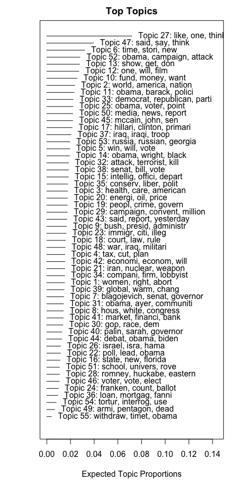

```r
plot(poliblog5k.fit.lee_mimno)
```

```r
labelTopics(poliblog5k.fit.lee_mimno)
```

```
Topic 1 Top Words:
     Highest Prob: women, right, abort, gay, marriag, issu, religi
     FREX: abort, gay, women, marriag, sex, religi, woman
     Lift: abort, gay, sex, marriag, sexual, women, prolif
     Score: abort, gay, women, marriag, sex, religi, sexual
Topic 2 Top Words:
     Highest Prob: world, america, nation, countri, american, foreign, will
     FREX: world, america, foreign, democraci, must, countri, freedom
     Lift: ahmadinejad, democraci, world, europ, diplomaci, abroad, freedom
     Score: ahmadinejad, world, foreign, america, democraci, countri, secur
Topic 3 Top Words:
     Highest Prob: health, care, american, famili, will, work, job
     FREX: health, care, union, worker, famili, insur, job
     Lift: auto, health, insur, worker, union, wage, minimum
     Score: auto, health, insur, worker, care, union, famili
Topic 4 Top Words:
     Highest Prob: tax, cut, plan, billion, spend, bailout, pay
     FREX: tax, bailout, cut, billion, spend, budget, pay
     Lift: bailout, tax, deficit, revenu, stimulus, budget, fiscal
     Score: bailout, tax, billion, spend, budget, stimulus, deficit
Topic 5 Top Words:
     Highest Prob: win, will, vote, state, elect, victori, can
     FREX: win, victori, elector, lose, michigan, won, pennsylvania
     Lift: battleground, win, elector, turnout, indiana, victori, momentum
     Score: battleground, win, vote, elector, victori, pennsylvania, turnout
Topic 6 Top Words:
     Highest Prob: time, stori, new, post, york, articl, read
     FREX: publish, page, stori, blog, piec, newspap, editor
     Lift: birth, publish, editor, newspap, editori, circul, page
     Score: birth, stori, publish, articl, book, newspap, editor
Topic 7 Top Words:
     Highest Prob: blagojevich, senat, governor, illinoi, seat, polit, rezko
     FREX: blagojevich, illinoi, rezko, appoint, corrupt, scandal, seat
     Lift: blagojevich, rezko, rod, jackson, probe, illinoi, toni
     Score: blagojevich, rezko, illinoi, rod, seat, chicago, governor
Topic 8 Top Words:
     Highest Prob: hous, white, congress, pelosi, committe, rep, member
     FREX: pelosi, hous, white, speaker, hill, congress, rep
     Lift: boehner, pelosi, capitol, speaker, nanci, hill, hous
     Score: boehner, hous, pelosi, white, congress, rep, speaker
```

[output cut: 220 more lines]

```
Topic 53 Top Words:
     Highest Prob: russia, russian, georgia, pakistan, govern, afghanistan, taliban
     FREX: russian, russia, taliban, pakistan, georgia, nato, pakistani
     Lift: taliban, afghan, russian, pakistani, nato, tribal, russia
     Score: taliban, russian, russia, pakistan, nato, pakistani, georgia
Topic 54 Top Words:
     Highest Prob: tortur, interrog, use, prison, techniqu, guantanamo, said
     FREX: interrog, tortur, techniqu, guantanamo, prison, legal, abu
     Lift: techniqu, interrog, tortur, guantanamo, abu, method, prison
     Score: techniqu, tortur, interrog, guantanamo, prison, abu, legal
Topic 55 Top Words:
     Highest Prob: withdraw, timet, obama, troop, iraq, polici, foreign
     FREX: timet, withdraw, troop, almaliki, date, prime, mission
     Lift: timet, withdraw, almaliki, date, mission, prime, troop
     Score: timet, withdraw, almaliki, troop, iraq, obama, iraqi
```

### Exclusivity, Semantic Coherence, Heldout Likelihood, and Residual Dispersion

NOTE: Running the six values of K below, and dedicating only one computer core to the task, the following takes **20 minutes** to run.

```r
system.time(
  poliblog5k.searchK <- searchK(documents = poliblog5k.docs,
                     vocab = poliblog5k.voc,
                     K = c(10,20,30,40,50,60), #specify K to try
                     N = 500, # matches 10% default
                     proportion = 0.5, # default
                     heldout.seed = 1234, # optional
                     M = 10, # default
                     cores = 1, # default
                     prevalence =~ rating + s(day),
                     max.em.its = 75,
                     data = poliblog5k.meta,
                     init.type = "Spectral",
                     verbose=TRUE)
)
```

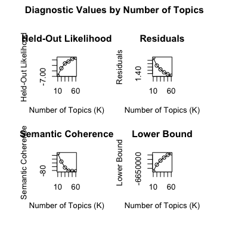

```r
plot(poliblog5k.searchK)
```

It’s hard to argue there’s a “true” $K$ in there.